# Income_Classification.R

anudeep

Fri Nov 11 16:40:04 2016

Given various features, the aim is to build a predictive model to determine the income level for people in US. The income levels are binned at below 50K and above 50K.

Train and Test datasets from UCI Machine Learning Repository The data is large and high dimensional. Used data.table for fast processing.

Let’s think of some hypothesis which can influence the outcome.

Here is a set of hypothesis: Hò : There is no significant impact of the variables (below) on the dependent variable. Ha : There exists a significant impact of the variables (below) on the dependent variable.

Age Marital Status Income Family Members No. of Dependents Tax Paid Investment (Mutual Fund, Stock) Return from Investments Education Spouse Education Nationality Occupation Region in US Race Occupation category

loading libraries

```r
library(data.table)
library(ggplot2)
library(plotly)
library(caret)
library(ROSE)
library(xgboost)
library(mlr)
```

loading data

```r
train <- fread('train.csv',na.strings = c(""," ","?","NA",NA))
test <- fread('test.csv',na.strings = c(""," ","?","NA",NA))
```

# DATA EXPLORATION

look at data

```r
dim(train)
```

```
## [1] 199523     41
```

```r
str (train)
```

```
## Classes 'data.table' and 'data.frame':   199523 obs. of  41 variables:
##  $ age                             : int  73 58 18 9 10 48 42 28 47 34 ...
##  $ class_of_worker                 : chr  "Not in universe" "Self-employed-not incorporated" "Not in universe" "Not in universe" ...
##  $ industry_code                   : int  0 4 0 0 0 40 34 4 43 4 ...
##  $ occupation_code                 : int  0 34 0 0 0 10 3 40 26 37 ...
##  $ education                       : chr  "High school graduate" "Some college but no degree" "10th grade" "Children" ...
##  $ wage_per_hour                   : int  0 0 0 0 0 1200 0 0 876 0 ...
##  $ enrolled_in_edu_inst_lastwk     : chr  "Not in universe" "Not in universe" "High school" "Not in universe" ...
##  $ marital_status                  : chr  "Widowed" "Divorced" "Never married" "Never married" ...
##  $ major_industry_code             : chr  "Not in universe or children" "Construction" "Not in universe or children" "Not in universe or children" ...
##  $ major_occupation_code           : chr  "Not in universe" "Precision production craft & repair" "Not in universe" "Not in universe" ...
##  $ race                            : chr  "White" "White" "Asian or Pacific Islander" "White" ...
##  $ hispanic_origin                 : chr  "All other" "All other" "All other" "All other" ...
##  $ sex                             : chr  "Female" "Male" "Female" "Female" ...
##  $ member_of_labor_union           : chr  "Not in universe" "Not in universe" "Not in universe" "Not in universe" ...
```

[output cut: 28 more lines]

```r
dim(test)
```

```
## [1] 99762    41
```

```r
str (test)
```

```
## Classes 'data.table' and 'data.frame':   99762 obs. of  41 variables:
##  $ age                             : int  38 44 2 35 49 13 1 61 38 7 ...
##  $ class_of_worker                 : chr  "Private" "Self-employed-not incorporated" "Not in universe" "Private" ...
##  $ industry_code                   : int  6 37 0 29 4 0 0 0 45 0 ...
##  $ occupation_code                 : int  36 12 0 3 34 0 0 0 12 0 ...
##  $ education                       : chr  "1st 2nd 3rd or 4th grade" "Associates degree-occup /vocational" "Children" "High school graduate" ...
##  $ wage_per_hour                   : int  0 0 0 0 0 0 0 0 0 0 ...
##  $ enrolled_in_edu_inst_lastwk     : chr  "Not in universe" "Not in universe" "Not in universe" "Not in universe" ...
##  $ marital_status                  : chr  "Married-civilian spouse present" "Married-civilian spouse present" "Never married" "Divorced" ...
##  $ major_industry_code             : chr  "Manufacturing-durable goods" "Business and repair services" "Not in universe or children" "Transportation" ...
##  $ major_occupation_code           : chr  "Machine operators assmblrs & inspctrs" "Professional specialty" "Not in universe" "Executive admin and managerial" ...
##  $ race                            : chr  "White" "White" "White" "White" ...
##  $ hispanic_origin                 : chr  "Mexican (Mexicano)" "All other" "Mexican-American" "All other" ...
##  $ sex                             : chr  "Female" "Female" "Male" "Female" ...
##  $ member_of_labor_union           : chr  "Not in universe" "Not in universe" "Not in universe" "Not in universe" ...
```

[output cut: 28 more lines]

Train data has 199523 rows & 41 columns. Test data has 99762 rows and 41 columns.

take a look at target variable

```r
unique(train$income_level)
```

```
## [1] "-50000" "+50000"
```

```r
unique(train$income_level)
```

```
## [1] "-50000" "+50000"
```

encode target variables

```r
train[, income_level := ifelse(income_level == "-50000",0,1)]
```

```
##         age                class_of_worker industry_code occupation_code
##      1:  73                Not in universe             0               0
##      2:  58 Self-employed-not incorporated             4              34
##      3:  18                Not in universe             0               0
##      4:   9                Not in universe             0               0
##      5:  10                Not in universe             0               0
##     ---
## 199519:  87                Not in universe             0               0
## 199520:  65     Self-employed-incorporated            37               2
## 199521:  47                Not in universe             0               0
## 199522:  16                Not in universe             0               0
## 199523:  32                        Private            42              30
##                          education wage_per_hour
##      1:       High school graduate             0
##      2: Some college but no degree             0
```

[output cut: 189 more lines]

```r
test[, income_level := ifelse(income_level == "-50000",0,1)]
```

```
##        age                class_of_worker industry_code occupation_code
##     1:  38                        Private             6              36
##     2:  44 Self-employed-not incorporated            37              12
##     3:   2                Not in universe             0               0
##     4:  35                        Private            29               3
##     5:  49                        Private             4              34
##    ---
## 99758:  14                Not in universe             0               0
## 99759:  61                        Private             8              36
## 99760:  24 Self-employed-not incorporated             1              43
## 99761:  30                        Private            45               2
## 99762:  67                Not in universe             0               0
##                                  education wage_per_hour
##     1:            1st 2nd 3rd or 4th grade             0
##     2: Associates degree-occup /vocational             0
```

[output cut: 177 more lines]

look at imbalanced classes

```r
round(prop.table(table(train$income_level))*100)
```

```
##
##  0  1
## 94  6
```

set column classes

```r
factcols <- c(2:5,7,8:16,20:29,31:38,40,41)
numcols <- setdiff(1:40,factcols)
```

With data table chaining, we can convert classes in one line

```r
train[,(factcols) := lapply(.SD, factor), .SDcols = factcols][,(numcols) := lapply(.SD, as.numeric), .SDcols = numcols]
```

```
##         age                class_of_worker industry_code occupation_code
##      1:  73                Not in universe             0               0
##      2:  58 Self-employed-not incorporated             4              34
##      3:  18                Not in universe             0               0
##      4:   9                Not in universe             0               0
##      5:  10                Not in universe             0               0
##     ---
## 199519:  87                Not in universe             0               0
## 199520:  65     Self-employed-incorporated            37               2
## 199521:  47                Not in universe             0               0
## 199522:  16                Not in universe             0               0
## 199523:  32                        Private            42              30
##                          education wage_per_hour
##      1:       High school graduate             0
##      2: Some college but no degree             0
```

[output cut: 189 more lines]

```r
test[,(factcols) := lapply(.SD, factor), .SDcols = factcols][,(numcols) := lapply(.SD, as.numeric), .SDcols = numcols]
```

```
##        age                class_of_worker industry_code occupation_code
##     1:  38                        Private             6              36
##     2:  44 Self-employed-not incorporated            37              12
##     3:   2                Not in universe             0               0
##     4:  35                        Private            29               3
##     5:  49                        Private             4              34
##    ---
## 99758:  14                Not in universe             0               0
## 99759:  61                        Private             8              36
## 99760:  24 Self-employed-not incorporated             1              43
## 99761:  30                        Private            45               2
## 99762:  67                Not in universe             0               0
##                                  education wage_per_hour
##     1:            1st 2nd 3rd or 4th grade             0
##     2: Associates degree-occup /vocational             0
```

[output cut: 177 more lines]

separate categorical variables and numerical variables

```r
num_train <- train[, numcols, with = FALSE]
cat_train <- train[, factcols, with = FALSE]
num_test <- test[, numcols, with = FALSE]
cat_test <- test[, factcols, with = FALSE]
```

save memory

```r
rm(train,test)
```

write a plot function

```r
plot_dist <- function(a){
  ggplot(data = num_train, aes(x= a, y=..density..)) + geom_histogram(fill="green",color="white",
                                        alpha = 0.5,bins =100) + geom_density()
  ggplotly()
}
```

checking distribution

```r
plot_dist(num_train$age)
```

[interactive chart not shown]

```r
plot_dist(num_train$wage_per_hour)
```

[interactive chart not shown]

plot_dist(num_train$capital_gains) plot_dist(num_train$capital_losses) plot_dist(num_train$dividend_from_Stocks) plot_dist(num_train$num_person_Worked_employer) plot_dist(num_train$weeks_worked_in_year)

Nothing interesting above except for age variable. Now let us see how variables affect our target

```r
num_train[, income_level := cat_train$income_level]
```

```
##         age wage_per_hour capital_gains capital_losses
##      1:  73             0             0              0
##      2:  58             0             0              0
##      3:  18             0             0              0
##      4:   9             0             0              0
##      5:  10             0             0              0
##     ---
## 199519:  87             0             0              0
## 199520:  65             0          6418              0
## 199521:  47             0             0              0
## 199522:  16             0             0              0
## 199523:  32             0             0              0
##         dividend_from_Stocks num_person_Worked_employer
##      1:                    0                          0
##      2:                    0                          1
```

[output cut: 21 more lines]

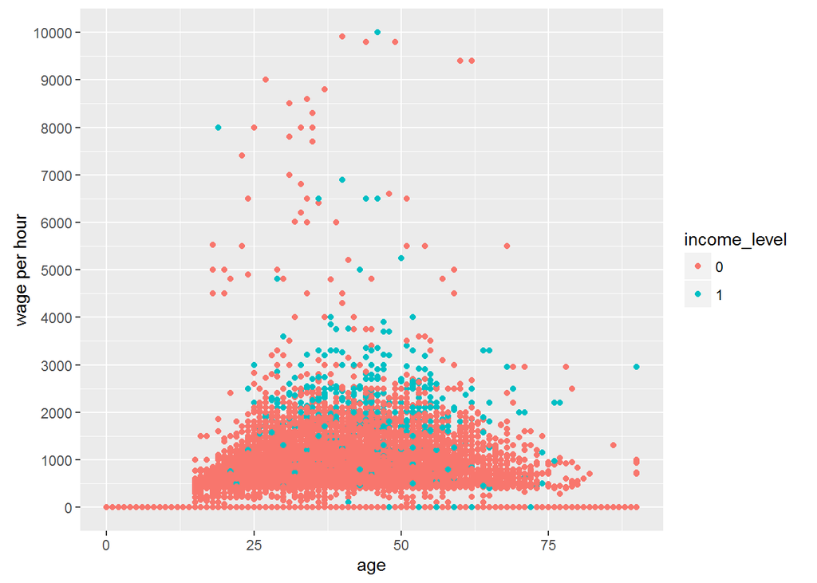

```r
ggplot(data = num_train, aes(x = age, y = wage_per_hour)) +
              geom_point(aes(colour = income_level)) +
              scale_y_continuous("wage per hour", breaks = seq(0,10000,1000))
```

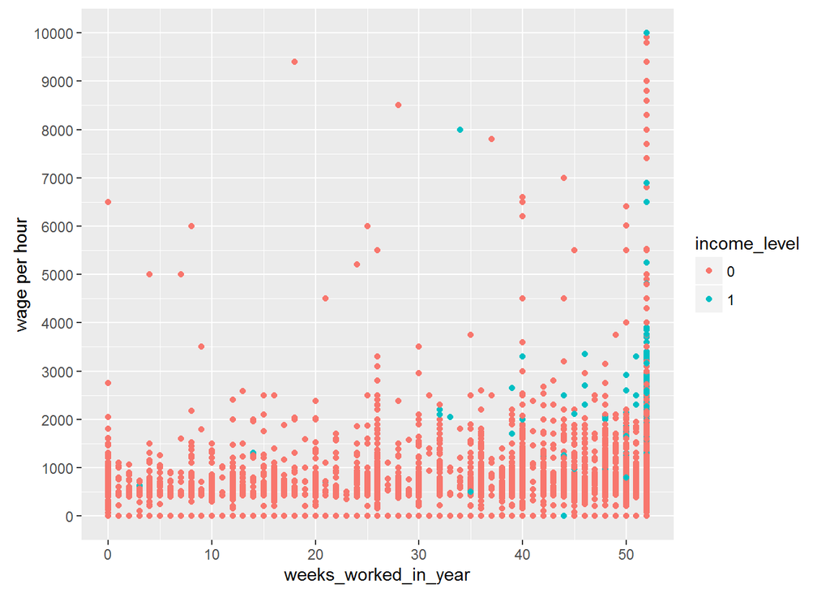

```r
ggplot(data = num_train, aes(x = weeks_worked_in_year, y = wage_per_hour)) +
  geom_point(aes(colour = income_level)) +
  scale_y_continuous("wage per hour", breaks = seq(0,10000,1000))
```

dodged bar chart function for categorical variables

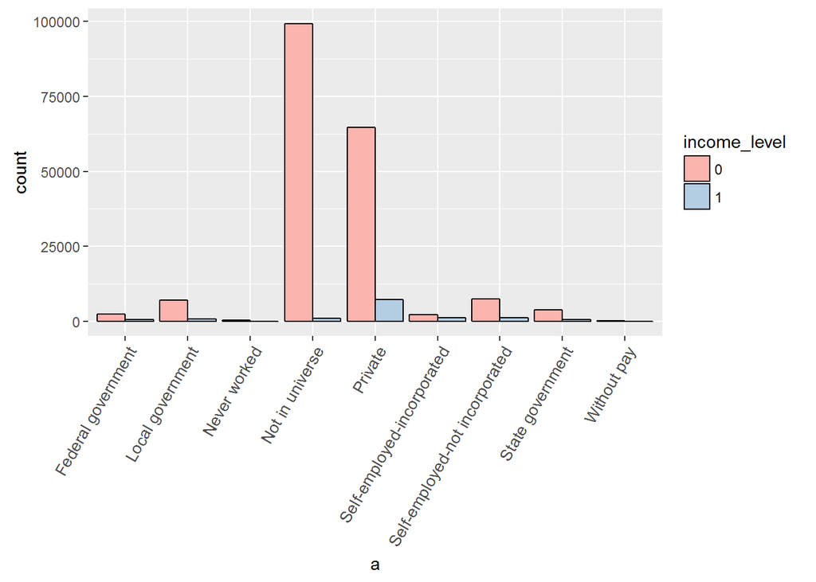

```r
plot_dodgedbar <- function(a){
  ggplot(cat_train, aes(x = a, fill = income_level)) +
    geom_bar(position = 'dodge', color = 'black') +
    scale_fill_brewer(palette = 'Pastel1') +
    theme(axis.text.x = element_text(angle = 60, hjust = 1, size = 10))
}
plot_dodgedbar(cat_train$class_of_worker)
```

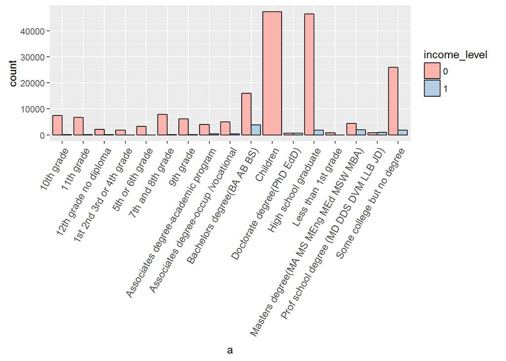

```r
plot_dodgedbar(cat_train$education)
```

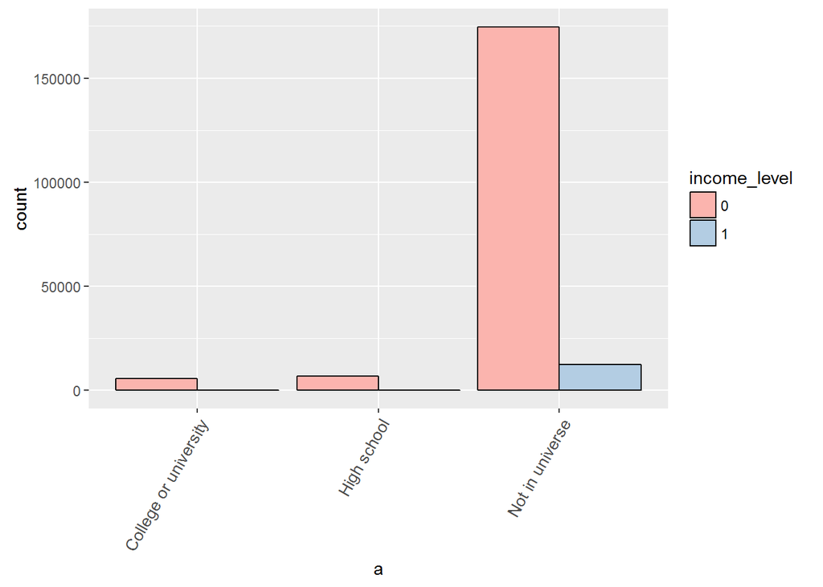

```r
plot_dodgedbar(cat_train$enrolled_in_edu_inst_lastwk)
```

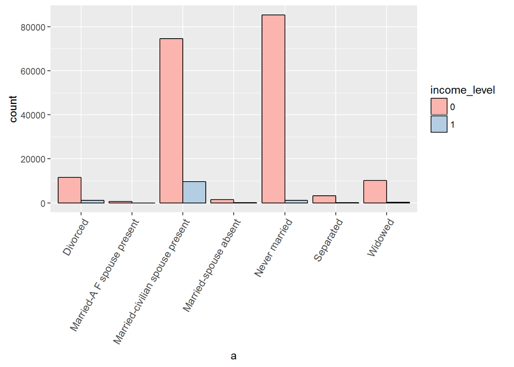

```r
plot_dodgedbar(cat_train$marital_status)
```

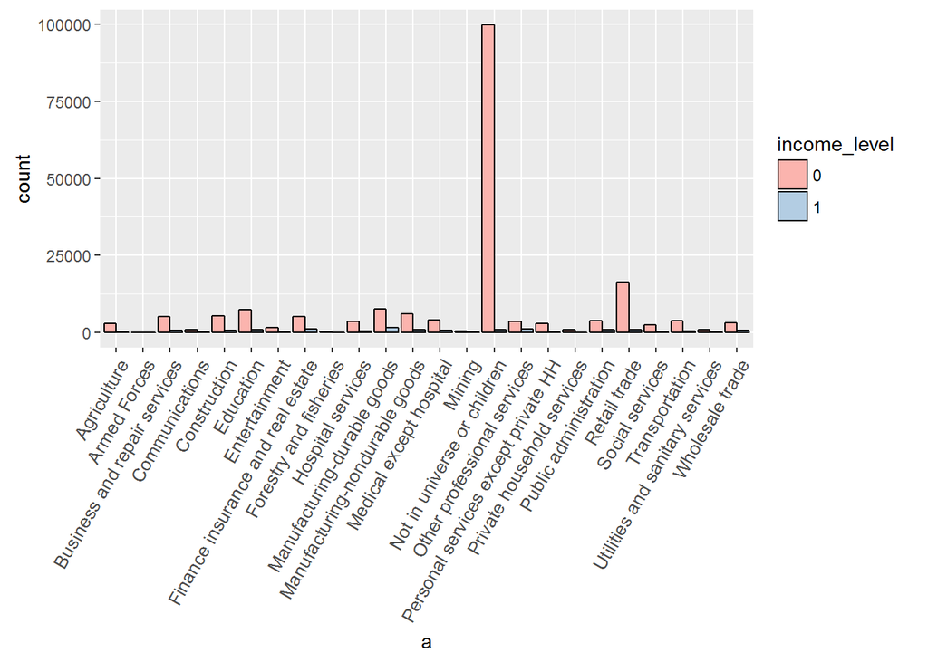

```r
plot_dodgedbar(cat_train$major_industry_code)
```

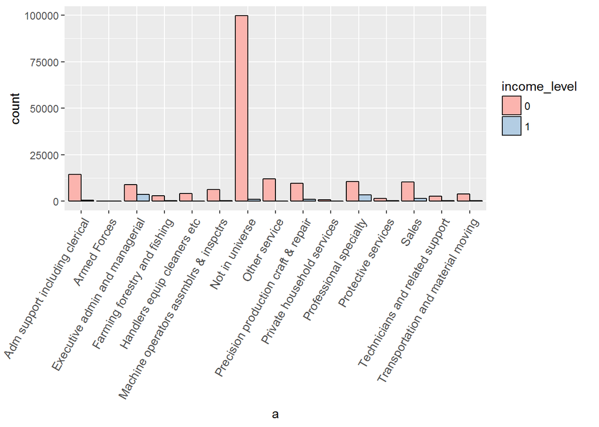

```r
plot_dodgedbar(cat_train$major_occupation_code)
```

proportion tables

```r
prop.table(table(cat_train$class_of_worker, cat_train$income_level),1)
```

```
##
##                                            0           1
##   Federal government             0.795897436 0.204102564
##   Local government               0.891187050 0.108812950
##   Never worked                   0.995444191 0.004555809
##   Not in universe                0.990982094 0.009017906
##   Private                        0.898345088 0.101654912
##   Self-employed-incorporated     0.652679939 0.347320061
##   Self-employed-not incorporated 0.870929544 0.129070456
##   State government               0.885261415 0.114738585
##   Without pay                    0.993939394 0.006060606
```

```r
prop.table(table(cat_train$marital_status, cat_train$income_level),1)
```

```
##
##                                            0          1
##   Divorced                        0.91612903 0.08387097
##   Married-A F spouse present      0.97744361 0.02255639
##   Married-civilian spouse present 0.88601553 0.11398447
##   Married-spouse absent           0.93675889 0.06324111
##   Never married                   0.98708447 0.01291553
##   Separated                       0.95433526 0.04566474
##   Widowed                         0.96846029 0.03153971
```

# DATA CLEANING

check missing values in numerical data - fortunately, no missing values here

```r
table(is.na(num_train))
```

```
##
##   FALSE
## 1596184
```

```r
table(is.na(num_test))
```

```
##
##  FALSE
## 698334
```

```r
num_train[, income_level := NULL]
```

```
##         age wage_per_hour capital_gains capital_losses
##      1:  73             0             0              0
##      2:  58             0             0              0
##      3:  18             0             0              0
##      4:   9             0             0              0
##      5:  10             0             0              0
##     ---
## 199519:  87             0             0              0
## 199520:  65             0          6418              0
## 199521:  47             0             0              0
## 199522:  16             0             0              0
## 199523:  32             0             0              0
##         dividend_from_Stocks num_person_Worked_employer
##      1:                    0                          0
##      2:                    0                          1
```

[output cut: 21 more lines]

check for correlation in numerical data

```r
correlatedvars <- findCorrelation(x = cor(num_train), cutoff = 0.7)
correlatedvars
```

```
## [1] 7
```

```r
#removing weeks_worked_in_year from both train and test
num_train <-num_train[, -correlatedvars, with = FALSE]
num_test <- num_test[, -correlatedvars, with = FALSE]
```

check for missing values proportion in categorical data

```r
missingvaluesprop_train <- sapply(cat_train, function(x){sum(is.na(x))/length(x)})*100
missingvaluesprop_train
```

```
##                  class_of_worker                    industry_code
##                        0.0000000                        0.0000000
##                  occupation_code                        education
##                        0.0000000                        0.0000000
##      enrolled_in_edu_inst_lastwk                   marital_status
##                        0.0000000                        0.0000000
##              major_industry_code            major_occupation_code
##                        0.0000000                        0.0000000
##                             race                  hispanic_origin
##                        0.0000000                        0.4380447
##                              sex            member_of_labor_union
##                        0.0000000                        0.0000000
##          reason_for_unemployment    full_parttime_employment_stat
##                        0.0000000                        0.0000000
##                 tax_filer_status     region_of_previous_residence
##                        0.0000000                        0.0000000
##      state_of_previous_residence          d_household_family_stat
##                        0.3548463                        0.0000000
##              d_household_summary                    migration_msa
##                        0.0000000                       49.9671717
##                    migration_reg             migration_within_reg
##                       49.9671717                       49.9671717
##                  live_1_year_ago                migration_sunbelt
##                        0.0000000                       49.9671717
##          family_members_under_18                   country_father
##                        0.0000000                        3.3645244
##                   country_mother                     country_self
##                        3.0668144                        1.7005558
##                      citizenship        business_or_self_employed
##                        0.0000000                        0.0000000
## fill_questionnaire_veteran_admin                veterans_benefits
##                        0.0000000                        0.0000000
##                             year                     income_level
##                        0.0000000                        0.0000000
```

```r
missingvaluesprop_test <- sapply(cat_test, function(x){sum(is.na(x))/length(x)})*100
missingvaluesprop_test
```

```
##                  class_of_worker                    industry_code
##                        0.0000000                        0.0000000
##                  occupation_code                        education
##                        0.0000000                        0.0000000
##      enrolled_in_edu_inst_lastwk                   marital_status
##                        0.0000000                        0.0000000
##              major_industry_code            major_occupation_code
##                        0.0000000                        0.0000000
##                             race                  hispanic_origin
##                        0.0000000                        0.4059662
##                              sex            member_of_labor_union
##                        0.0000000                        0.0000000
##          reason_for_unemployment    full_parttime_employment_stat
##                        0.0000000                        0.0000000
##                 tax_filer_status     region_of_previous_residence
##                        0.0000000                        0.0000000
##      state_of_previous_residence          d_household_family_stat
##                        0.3307873                        0.0000000
##              d_household_summary                    migration_msa
##                        0.0000000                       50.0651551
##                    migration_reg             migration_within_reg
##                       50.0651551                       50.0651551
##                  live_1_year_ago                migration_sunbelt
##                        0.0000000                       50.0651551
##          family_members_under_18                   country_father
##                        0.0000000                        3.4371805
##                   country_mother                     country_self
##                        3.0793288                        1.7682083
##                      citizenship        business_or_self_employed
##                        0.0000000                        0.0000000
## fill_questionnaire_veteran_admin                veterans_benefits
##                        0.0000000                        0.0000000
##                             year                     income_level
##                        0.0000000                        0.0000000
```

select only variables which have missing values proportion < 5%

```r
cat_train <- subset(cat_train, select = missingvaluesprop_train < 5)
cat_test <- subset(cat_test, select = missingvaluesprop_test < 5)
```

set NA as Unavailable - train data

```r
#convert to characters
cat_train <- cat_train[,names(cat_train) := lapply(.SD, as.character),.SDcols = names(cat_train)]
for (i in seq_along(cat_train)){
  set(cat_train, i=which(is.na(cat_train[[i]])), j=i, value="Unavailable")
}
str(cat_train)
```

```
## Classes 'data.table' and 'data.frame':   199523 obs. of  30 variables:
##  $ class_of_worker                 : chr  "Not in universe" "Self-employed-not incorporated" "Not in universe" "Not in universe" ...
##  $ industry_code                   : chr  "0" "4" "0" "0" ...
##  $ occupation_code                 : chr  "0" "34" "0" "0" ...
##  $ education                       : chr  "High school graduate" "Some college but no degree" "10th grade" "Children" ...
##  $ enrolled_in_edu_inst_lastwk     : chr  "Not in universe" "Not in universe" "High school" "Not in universe" ...
##  $ marital_status                  : chr  "Widowed" "Divorced" "Never married" "Never married" ...
##  $ major_industry_code             : chr  "Not in universe or children" "Construction" "Not in universe or children" "Not in universe or children" ...
##  $ major_occupation_code           : chr  "Not in universe" "Precision production craft & repair" "Not in universe" "Not in universe" ...
##  $ race                            : chr  "White" "White" "Asian or Pacific Islander" "White" ...
##  $ hispanic_origin                 : chr  "All other" "All other" "All other" "All other" ...
##  $ sex                             : chr  "Female" "Male" "Female" "Female" ...
##  $ member_of_labor_union           : chr  "Not in universe" "Not in universe" "Not in universe" "Not in universe" ...
##  $ reason_for_unemployment         : chr  "Not in universe" "Not in universe" "Not in universe" "Not in universe" ...
##  $ full_parttime_employment_stat   : chr  "Not in labor force" "Children or Armed Forces" "Not in labor force" "Children or Armed Forces" ...
```

[output cut: 17 more lines]

```r
#convert back to factors
cat_train <- cat_train[, names(cat_train) := lapply(.SD,factor), .SDcols = names(cat_train)]
str(cat_train)
```

```
## Classes 'data.table' and 'data.frame':   199523 obs. of  30 variables:
##  $ class_of_worker                 : Factor w/ 9 levels "Federal government",..: 4 7 4 4 4 5 5 5 2 5 ...
##  $ industry_code                   : Factor w/ 52 levels "0","1","10","11",..: 1 35 1 1 1 36 29 35 39 35 ...
##  $ occupation_code                 : Factor w/ 47 levels "0","1","10","11",..: 1 29 1 1 1 3 24 36 20 32 ...
##  $ education                       : Factor w/ 17 levels "10th grade","11th grade",..: 13 17 1 11 11 17 10 13 17 17 ...
##  $ enrolled_in_edu_inst_lastwk     : Factor w/ 3 levels "College or university",..: 3 3 2 3 3 3 3 3 3 3 ...
##  $ marital_status                  : Factor w/ 7 levels "Divorced","Married-A F spouse present",..: 7 1 5 5 5 3 3 5 3 3 ...
##  $ major_industry_code             : Factor w/ 24 levels "Agriculture",..: 15 5 15 15 15 7 8 5 6 5 ...
##  $ major_occupation_code           : Factor w/ 15 levels "Adm support including clerical",..: 7 9 7 7 7 11 3 5 1 6 ...
##  $ race                            : Factor w/ 5 levels "Amer Indian Aleut or Eskimo",..: 5 5 2 5 5 1 5 5 5 5 ...
##  $ hispanic_origin                 : Factor w/ 10 levels "All other","Central or South American",..: 1 1 1 1 1 1 1 1 1 1 ...
##  $ sex                             : Factor w/ 2 levels "Female","Male": 1 2 1 1 1 1 2 1 1 2 ...
##  $ member_of_labor_union           : Factor w/ 3 levels "No","Not in universe",..: 2 2 2 2 2 1 2 2 1 2 ...
##  $ reason_for_unemployment         : Factor w/ 6 levels "Job leaver","Job loser - on layoff",..: 4 4 4 4 4 4 4 2 4 4 ...
##  $ full_parttime_employment_stat   : Factor w/ 8 levels "Children or Armed Forces",..: 3 1 3 1 1 2 1 7 2 1 ...
```

[output cut: 17 more lines]

set NA as Unavailable - test data

```r
cat_test <- cat_test[, (names(cat_test)) := lapply(.SD, as.character), .SDcols = names(cat_test)]
for (i in seq_along(cat_test)){
  set(cat_test, i=which(is.na(cat_test[[i]])), j=i, value="Unavailable")
}
str(cat_test)
```

```
## Classes 'data.table' and 'data.frame':   99762 obs. of  30 variables:
##  $ class_of_worker                 : chr  "Private" "Self-employed-not incorporated" "Not in universe" "Private" ...
##  $ industry_code                   : chr  "6" "37" "0" "29" ...
##  $ occupation_code                 : chr  "36" "12" "0" "3" ...
##  $ education                       : chr  "1st 2nd 3rd or 4th grade" "Associates degree-occup /vocational" "Children" "High school graduate" ...
##  $ enrolled_in_edu_inst_lastwk     : chr  "Not in universe" "Not in universe" "Not in universe" "Not in universe" ...
##  $ marital_status                  : chr  "Married-civilian spouse present" "Married-civilian spouse present" "Never married" "Divorced" ...
##  $ major_industry_code             : chr  "Manufacturing-durable goods" "Business and repair services" "Not in universe or children" "Transportation" ...
##  $ major_occupation_code           : chr  "Machine operators assmblrs & inspctrs" "Professional specialty" "Not in universe" "Executive admin and managerial" ...
##  $ race                            : chr  "White" "White" "White" "White" ...
##  $ hispanic_origin                 : chr  "Mexican (Mexicano)" "All other" "Mexican-American" "All other" ...
##  $ sex                             : chr  "Female" "Female" "Male" "Female" ...
##  $ member_of_labor_union           : chr  "Not in universe" "Not in universe" "Not in universe" "Not in universe" ...
##  $ reason_for_unemployment         : chr  "Not in universe" "Not in universe" "Not in universe" "Not in universe" ...
##  $ full_parttime_employment_stat   : chr  "Full-time schedules" "PT for econ reasons usually PT" "Children or Armed Forces" "Children or Armed Forces" ...
```

[output cut: 17 more lines]

```r
#convert back to factors
cat_test <- cat_test[, (names(cat_test)) := lapply(.SD, factor), .SDcols = names(cat_test)]
str(cat_test)
```

```
## Classes 'data.table' and 'data.frame':   99762 obs. of  30 variables:
##  $ class_of_worker                 : Factor w/ 9 levels "Federal government",..: 5 7 4 5 5 4 4 4 5 4 ...
##  $ industry_code                   : Factor w/ 52 levels "0","1","10","11",..: 49 32 1 23 35 1 1 1 41 1 ...
##  $ occupation_code                 : Factor w/ 47 levels "0","1","10","11",..: 31 5 1 24 29 1 1 1 5 1 ...
##  $ education                       : Factor w/ 17 levels "10th grade","11th grade",..: 4 9 11 13 13 11 11 13 15 11 ...
##  $ enrolled_in_edu_inst_lastwk     : Factor w/ 3 levels "College or university",..: 3 3 3 3 3 3 3 3 3 3 ...
##  $ marital_status                  : Factor w/ 7 levels "Divorced","Married-A F spouse present",..: 3 3 5 1 1 5 5 3 3 5 ...
##  $ major_industry_code             : Factor w/ 24 levels "Agriculture",..: 11 3 15 22 5 15 15 15 16 15 ...
##  $ major_occupation_code           : Factor w/ 15 levels "Adm support including clerical",..: 6 11 7 3 9 7 7 7 11 7 ...
##  $ race                            : Factor w/ 5 levels "Amer Indian Aleut or Eskimo",..: 5 5 5 5 5 5 5 5 3 5 ...
##  $ hispanic_origin                 : Factor w/ 10 levels "All other","Central or South American",..: 7 1 6 1 1 1 6 1 1 1 ...
##  $ sex                             : Factor w/ 2 levels "Female","Male": 1 1 2 1 2 2 1 1 2 1 ...
##  $ member_of_labor_union           : Factor w/ 3 levels "No","Not in universe",..: 2 2 2 2 2 2 2 2 2 2 ...
##  $ reason_for_unemployment         : Factor w/ 6 levels "Job leaver","Job loser - on layoff",..: 4 4 4 4 4 4 4 4 4 4 ...
##  $ full_parttime_employment_stat   : Factor w/ 8 levels "Children or Armed Forces",..: 2 5 1 1 2 1 1 3 1 1 ...
```

[output cut: 17 more lines]

# DATA MANIPULATION

combine factor levels with less than 5% values because we saw that categorical columns have several levels with very low frequencies which can hinder our model performance

```r
#train
for(i in names(cat_train)){
  p <- 5/100
  ld <- names(which(prop.table(table(cat_train[[i]])) < p))
  levels(cat_train[[i]])[levels(cat_train[[i]]) %in% ld] <- "Other"
}
```

```r
#test
for(i in names(cat_test)){
  p <- 5/100
  ld <- names(which(prop.table(table(cat_test[[i]])) < p))
  levels(cat_test[[i]])[levels(cat_test[[i]]) %in% ld] <- "Other"
}
```

check columns with unequal levels - mlr package comes handy

```r
summarizeColumns(cat_train)[, 'nlevs']
```

```
##  [1] 3 3 2 5 2 5 3 8 3 2 2 3 2 4 4 2 2 6 5 3 4 3 2 2 3 3 2 3 2 2
```

```r
summarizeColumns(cat_test)[, 'nlevs']
```

```
##  [1] 3 3 2 5 2 5 3 8 3 2 2 3 2 4 4 2 2 6 5 3 4 3 2 2 3 3 2 3 2 2
```

```r
num_train[, .N, age][order(age)]
```

```
##     age    N
##  1:   0 2839
##  2:   1 3138
##  3:   2 3236
##  4:   3 3279
##  5:   4 3318
##  6:   5 3332
##  7:   6 3171
##  8:   7 3218
##  9:   8 3187
## 10:   9 3162
## 11:  10 3134
## 12:  11 3128
## 13:  12 3060
## 14:  13 3152
```

[output cut: 78 more lines]

```r
num_train[, .N, wage_per_hour][order(-N)]
```

```
##       wage_per_hour      N
##    1:             0 188219
##    2:           500    734
##    3:           600    546
##    4:           700    534
##    5:           800    507
##   ---
## 1236:           724      1
## 1237:          1376      1
## 1238:          3156      1
## 1239:          2188      1
## 1240:          1092      1
```

Binning numerical variables

```r
num_train[, age := cut(age, breaks = c(0,30,60,90), labels = c("young","adult","old"),
                       include.lowest = TRUE)]
```

```
##           age wage_per_hour capital_gains capital_losses
##      1:   old             0             0              0
##      2: adult             0             0              0
##      3: young             0             0              0
##      4: young             0             0              0
##      5: young             0             0              0
##     ---
## 199519:   old             0             0              0
## 199520:   old             0          6418              0
## 199521: adult             0             0              0
## 199522: young             0             0              0
## 199523: adult             0             0              0
##         dividend_from_Stocks num_person_Worked_employer
##      1:                    0                          0
##      2:                    0                          1
##      3:                    0                          0
##      4:                    0                          0
##      5:                    0                          0
##     ---
## 199519:                    0                          0
## 199520:                    9                          1
## 199521:                  157                          6
## 199522:                    0                          0
## 199523:                    0                          6
```

```r
num_test[, age := cut(age, breaks = c(0,30,60,90), labels = c("young","adult","old"),
                       include.lowest = TRUE)]
```

```
##          age wage_per_hour capital_gains capital_losses
##     1: adult             0             0              0
##     2: adult             0             0              0
##     3: young             0             0              0
##     4: adult             0             0              0
##     5: adult             0             0              0
##    ---
## 99758: young             0             0              0
## 99759:   old             0             0              0
## 99760: young             0             0              0
## 99761: young             0             0              0
## 99762:   old             0             0              0
##        dividend_from_Stocks num_person_Worked_employer
##     1:                    0                          4
##     2:                 2500                          1
##     3:                    0                          0
##     4:                    0                          5
##     5:                    0                          4
##    ---
## 99758:                    0                          0
## 99759:                    0                          4
## 99760:                    0                          2
## 99761:                    0                          5
## 99762:                    0                          0
```

Bin numeric variables with Zero and MoreThanZero

```r
num_train[,wage_per_hour := ifelse(wage_per_hour == 0,"Zero","MoreThanZero")][,wage_per_hour := as.factor(wage_per_hour)]
```

```
##           age wage_per_hour capital_gains capital_losses
##      1:   old          Zero             0              0
##      2: adult          Zero             0              0
##      3: young          Zero             0              0
##      4: young          Zero             0              0
##      5: young          Zero             0              0
##     ---
## 199519:   old          Zero             0              0
## 199520:   old          Zero          6418              0
## 199521: adult          Zero             0              0
## 199522: young          Zero             0              0
## 199523: adult          Zero             0              0
##         dividend_from_Stocks num_person_Worked_employer
##      1:                    0                          0
##      2:                    0                          1
##      3:                    0                          0
##      4:                    0                          0
##      5:                    0                          0
##     ---
## 199519:                    0                          0
## 199520:                    9                          1
## 199521:                  157                          6
## 199522:                    0                          0
## 199523:                    0                          6
```

```r
num_train[,capital_gains := ifelse(capital_gains == 0,"Zero","MoreThanZero")][,capital_gains := as.factor(capital_gains)]
```

```
##           age wage_per_hour capital_gains capital_losses
##      1:   old          Zero          Zero              0
##      2: adult          Zero          Zero              0
##      3: young          Zero          Zero              0
##      4: young          Zero          Zero              0
##      5: young          Zero          Zero              0
##     ---
## 199519:   old          Zero          Zero              0
## 199520:   old          Zero  MoreThanZero              0
## 199521: adult          Zero          Zero              0
## 199522: young          Zero          Zero              0
## 199523: adult          Zero          Zero              0
##         dividend_from_Stocks num_person_Worked_employer
##      1:                    0                          0
##      2:                    0                          1
##      3:                    0                          0
##      4:                    0                          0
##      5:                    0                          0
##     ---
## 199519:                    0                          0
## 199520:                    9                          1
## 199521:                  157                          6
## 199522:                    0                          0
## 199523:                    0                          6
```

```r
num_train[,capital_losses := ifelse(capital_losses == 0,"Zero","MoreThanZero")][,capital_losses := as.factor(capital_losses)]
```

```
##           age wage_per_hour capital_gains capital_losses
##      1:   old          Zero          Zero           Zero
##      2: adult          Zero          Zero           Zero
##      3: young          Zero          Zero           Zero
##      4: young          Zero          Zero           Zero
##      5: young          Zero          Zero           Zero
##     ---
## 199519:   old          Zero          Zero           Zero
## 199520:   old          Zero  MoreThanZero           Zero
## 199521: adult          Zero          Zero           Zero
## 199522: young          Zero          Zero           Zero
## 199523: adult          Zero          Zero           Zero
##         dividend_from_Stocks num_person_Worked_employer
##      1:                    0                          0
##      2:                    0                          1
##      3:                    0                          0
##      4:                    0                          0
##      5:                    0                          0
##     ---
## 199519:                    0                          0
## 199520:                    9                          1
## 199521:                  157                          6
## 199522:                    0                          0
## 199523:                    0                          6
```

```r
num_train[,dividend_from_Stocks := ifelse(dividend_from_Stocks == 0,"Zero","MoreThanZero")][,dividend_from_Stocks := as.factor(dividend_from_Stocks)]
```

```
##           age wage_per_hour capital_gains capital_losses
##      1:   old          Zero          Zero           Zero
##      2: adult          Zero          Zero           Zero
##      3: young          Zero          Zero           Zero
##      4: young          Zero          Zero           Zero
##      5: young          Zero          Zero           Zero
##     ---
## 199519:   old          Zero          Zero           Zero
## 199520:   old          Zero  MoreThanZero           Zero
## 199521: adult          Zero          Zero           Zero
## 199522: young          Zero          Zero           Zero
## 199523: adult          Zero          Zero           Zero
##         dividend_from_Stocks num_person_Worked_employer
##      1:                 Zero                          0
##      2:                 Zero                          1
##      3:                 Zero                          0
##      4:                 Zero                          0
##      5:                 Zero                          0
##     ---
## 199519:                 Zero                          0
## 199520:         MoreThanZero                          1
## 199521:         MoreThanZero                          6
## 199522:                 Zero                          0
## 199523:                 Zero                          6
```

```r
num_test[,wage_per_hour := ifelse(wage_per_hour == 0,"Zero","MoreThanZero")][,wage_per_hour := as.factor(wage_per_hour)]
```

```
##          age wage_per_hour capital_gains capital_losses
##     1: adult          Zero             0              0
##     2: adult          Zero             0              0
##     3: young          Zero             0              0
##     4: adult          Zero             0              0
##     5: adult          Zero             0              0
##    ---
## 99758: young          Zero             0              0
## 99759:   old          Zero             0              0
## 99760: young          Zero             0              0
## 99761: young          Zero             0              0
## 99762:   old          Zero             0              0
##        dividend_from_Stocks num_person_Worked_employer
##     1:                    0                          4
##     2:                 2500                          1
##     3:                    0                          0
##     4:                    0                          5
##     5:                    0                          4
##    ---
## 99758:                    0                          0
## 99759:                    0                          4
## 99760:                    0                          2
## 99761:                    0                          5
## 99762:                    0                          0
```

```r
num_test[,capital_gains := ifelse(capital_gains == 0,"Zero","MoreThanZero")][,capital_gains := as.factor(capital_gains)]
```

```
##          age wage_per_hour capital_gains capital_losses
##     1: adult          Zero          Zero              0
##     2: adult          Zero          Zero              0
##     3: young          Zero          Zero              0
##     4: adult          Zero          Zero              0
##     5: adult          Zero          Zero              0
##    ---
## 99758: young          Zero          Zero              0
## 99759:   old          Zero          Zero              0
## 99760: young          Zero          Zero              0
## 99761: young          Zero          Zero              0
## 99762:   old          Zero          Zero              0
##        dividend_from_Stocks num_person_Worked_employer
##     1:                    0                          4
##     2:                 2500                          1
##     3:                    0                          0
##     4:                    0                          5
##     5:                    0                          4
##    ---
## 99758:                    0                          0
## 99759:                    0                          4
## 99760:                    0                          2
## 99761:                    0                          5
## 99762:                    0                          0
```

```r
num_test[,capital_losses := ifelse(capital_losses == 0,"Zero","MoreThanZero")][,capital_losses := as.factor(capital_losses)]
```

```
##          age wage_per_hour capital_gains capital_losses
##     1: adult          Zero          Zero           Zero
##     2: adult          Zero          Zero           Zero
##     3: young          Zero          Zero           Zero
##     4: adult          Zero          Zero           Zero
##     5: adult          Zero          Zero           Zero
##    ---
## 99758: young          Zero          Zero           Zero
## 99759:   old          Zero          Zero           Zero
## 99760: young          Zero          Zero           Zero
## 99761: young          Zero          Zero           Zero
## 99762:   old          Zero          Zero           Zero
##        dividend_from_Stocks num_person_Worked_employer
##     1:                    0                          4
##     2:                 2500                          1
##     3:                    0                          0
##     4:                    0                          5
##     5:                    0                          4
##    ---
## 99758:                    0                          0
## 99759:                    0                          4
## 99760:                    0                          2
## 99761:                    0                          5
## 99762:                    0                          0
```

```r
num_test[,dividend_from_Stocks := ifelse(dividend_from_Stocks == 0,"Zero","MoreThanZero")][,dividend_from_Stocks := as.factor(dividend_from_Stocks)]
```

```
##          age wage_per_hour capital_gains capital_losses
##     1: adult          Zero          Zero           Zero
##     2: adult          Zero          Zero           Zero
##     3: young          Zero          Zero           Zero
##     4: adult          Zero          Zero           Zero
##     5: adult          Zero          Zero           Zero
##    ---
## 99758: young          Zero          Zero           Zero
## 99759:   old          Zero          Zero           Zero
## 99760: young          Zero          Zero           Zero
## 99761: young          Zero          Zero           Zero
## 99762:   old          Zero          Zero           Zero
##        dividend_from_Stocks num_person_Worked_employer
##     1:                 Zero                          4
##     2:         MoreThanZero                          1
##     3:                 Zero                          0
##     4:                 Zero                          5
##     5:                 Zero                          4
##    ---
## 99758:                 Zero                          0
## 99759:                 Zero                          4
## 99760:                 Zero                          2
## 99761:                 Zero                          5
## 99762:                 Zero                          0
```

# MODEL DEVELOPMENT

```r
train <- cbind(num_train, cat_train)
test <- cbind(num_test, cat_test)
```

mlr provides nice function makeClassifTask can convert train and test to data frames instead of data tables if we want to avoid warnings

```r
train.task <- makeClassifTask(data = train, target = "income_level")
```

```
## Warning in makeTask(type = type, data = data, weights = weights, blocking
## = blocking, : Provided data is not a pure data.frame but from class
## data.table, hence it will be converted.
```

```r
test.task<- makeClassifTask(data = test, target = "income_level")
```

```
## Warning in makeTask(type = type, data = data, weights = weights, blocking
## = blocking, : Provided data is not a pure data.frame but from class
## data.table, hence it will be converted.
```

```r
#remove constant variables with no variance
train.task <- removeConstantFeatures(train.task)
test.task <- removeConstantFeatures(test.task)
```

As our data is highly imbalanced, lets SMOTE it. In SMOTE, the algorithm looks at n nearest neighbors, measures the distance between them and introduces a new observation at the center of n observations.Its better than undersampling and oversampling rate = 10 makes minority class 10 times

```r
train.smote <- smote(train.task,rate = 10,nn = 3)
table(getTaskTargets(train.smote))
```

```
##
##      0      1
## 187141 123820
```

lets see which algorithms are available for binary classification

```r
listLearners("classif","twoclass")[c("class","package")]
```

```
##                   class      package
## 1           classif.ada          ada
## 2        classif.avNNet         nnet
## 3      classif.binomial        stats
## 4      classif.boosting adabag,rpart
## 5           classif.gbm          gbm
## 6           classif.IBk        RWeka
## 7           classif.J48        RWeka
## 8          classif.JRip        RWeka
## 9           classif.knn        class
## 10          classif.lda         MASS
## 11       classif.logreg        stats
## 12         classif.lvq1        class
## 13     classif.multinom         nnet
## 14   classif.naiveBayes        e1071
## 15         classif.nnet         nnet
## 16         classif.OneR        RWeka
## 17         classif.PART        RWeka
## 18   classif.plsdaCaret        caret
## 19       classif.probit        stats
## 20          classif.qda         MASS
## 21 classif.randomForest randomForest
## 22        classif.rpart        rpart
## 23          classif.svm        e1071
## 24      classif.xgboost      xgboost
```

naive Bayes

```r
naive_learner <- makeLearner("classif.naiveBayes",predict.type = "response")
naive_learner$par.vals <- list(laplace = 1)
```

10fold CV - stratified

```r
folds <- makeResampleDesc("CV",iters=10,stratify = TRUE)
```

cross validation function

```r
fun_cv <- function(a){
  crv_val <- resample(naive_learner,a,folds,measures = list(acc,tpr,tnr,fpr,fp,fn))
  crv_val$aggr
}
#Lets check whether train data or smoted train data is better

fun_cv(train.task)
```

```
## [Resample] cross-validation iter: 1
```

```
## [Resample] cross-validation iter: 2
```

```
## [Resample] cross-validation iter: 3
```

```
## [Resample] cross-validation iter: 4
```

```
## [Resample] cross-validation iter: 5
```

```
## [Resample] cross-validation iter: 6
```

```
## [Resample] cross-validation iter: 7
```

```
## [Resample] cross-validation iter: 8
```

```
## [Resample] cross-validation iter: 9
```

```
## [Resample] cross-validation iter: 10
```

```
## [Resample] Result: acc.test.mean=0.732,tpr.test.mean=0.721,tnr.test.mean=0.896,fpr.test.mean=0.104,fp.test.mean= 129,fn.test.mean=5.21e+03
```

```
## acc.test.mean tpr.test.mean tnr.test.mean fpr.test.mean  fp.test.mean
##     0.7322614     0.7214186     0.8961386     0.1038614   128.6000000
##  fn.test.mean
##  5213.4000000
```

```r
fun_cv(train.smote)
```

```
## [Resample] cross-validation iter: 1
```

```
## [Resample] cross-validation iter: 2
```

```
## [Resample] cross-validation iter: 3
```

```
## [Resample] cross-validation iter: 4
```

```
## [Resample] cross-validation iter: 5
```

```
## [Resample] cross-validation iter: 6
```

```
## [Resample] cross-validation iter: 7
```

```
## [Resample] cross-validation iter: 8
```

```
## [Resample] cross-validation iter: 9
```

```
## [Resample] cross-validation iter: 10
```

```
## [Resample] Result: acc.test.mean=0.872,tpr.test.mean=0.826,tnr.test.mean=0.943,fpr.test.mean=0.057,fp.test.mean= 706,fn.test.mean=3.26e+03
```

```
## acc.test.mean tpr.test.mean tnr.test.mean fpr.test.mean  fp.test.mean
##  8.723731e-01  8.256609e-01  9.429737e-01  5.702633e-02  7.061000e+02
##  fn.test.mean
##  3.262600e+03
```

we can see that smoted data has given better results

train and predict

```r
nB_model <- train(naive_learner, train.smote)
nB_predict <- predict(nB_model,test.task)
```

evaluate

```r
nB_prediction <- nB_predict$data$response
dCM <- confusionMatrix(test$income_level,nB_prediction)
dCM
```

```
## $positive
## [1] "0"
##
## $table
##           Reference
## Prediction     0     1
##          0 77305 16271
##          1  1073  5113
##
## $overall
##       Accuracy          Kappa  AccuracyLower  AccuracyUpper   AccuracyNull
##   8.261462e-01   3.039587e-01   8.237800e-01   8.284935e-01   7.856498e-01
## AccuracyPValue  McnemarPValue
##  2.568290e-224   0.000000e+00
##
## $byClass
##          Sensitivity          Specificity       Pos Pred Value
##            0.9863099            0.2391040            0.8261199
##       Neg Pred Value            Precision               Recall
##            0.8265438            0.8261199            0.9863099
##                   F1           Prevalence       Detection Rate
##            0.8991358            0.7856498            0.7748942
## Detection Prevalence    Balanced Accuracy
##            0.9379924            0.6127070
##
## $mode
## [1] "sens_spec"
##
## $dots
## list()
##
## attr(,"class")
## [1] "confusionMatrix"
```

we can see that it did failed at predicting minority class

calculate F measure

```r
precision <- dCM$byClass['Pos Pred Value']
recall <- dCM$byClass['Sensitivity']

f_measure <- 2*((precision*recall)/(precision+recall))
f_measure
```

```
## Pos Pred Value
##      0.8991358
```

Trying xgboost

```r
#xgboost
set.seed(2002)
xgb_learner <- makeLearner("classif.xgboost",predict.type = "response")
xgb_learner$par.vals <- list(
  objective = "binary:logistic",
  eval_metric = "error",
  nrounds = 150,
  print.every.n = 50
)
```

define hyperparameters for tuning

```r
xg_ps <- makeParamSet(
  makeIntegerParam("max_depth",lower=3,upper=10),
  makeNumericParam("lambda",lower=0.05,upper=0.5),
  makeNumericParam("eta", lower = 0.01, upper = 0.5),
  makeNumericParam("subsample", lower = 0.50, upper = 1),
  makeNumericParam("min_child_weight",lower=2,upper=10),
  makeNumericParam("colsample_bytree",lower = 0.50,upper = 0.80)
)
```

```r
#define search function
rancontrol <- makeTuneControlRandom(maxit = 5L) #do 5 iterations

#5 fold cross validation
set_cv <- makeResampleDesc("CV",iters = 5L,stratify = TRUE)

#tune parameters
xgb_tune <- tuneParams(learner = xgb_learner, task = train.task, resampling = set_cv,
                       measures = list(acc,tpr,tnr,fpr,fp,fn), par.set = xg_ps,
                       control = rancontrol)
```

```
## [Tune] Started tuning learner classif.xgboost for parameter set:
```

```
##                     Type len Def      Constr Req Tunable Trafo
## max_depth        integer   -   -     3 to 10   -    TRUE     -
## lambda           numeric   -   - 0.05 to 0.5   -    TRUE     -
## eta              numeric   -   - 0.01 to 0.5   -    TRUE     -
## subsample        numeric   -   -    0.5 to 1   -    TRUE     -
## min_child_weight numeric   -   -     2 to 10   -    TRUE     -
## colsample_bytree numeric   -   -  0.5 to 0.8   -    TRUE     -
```

```
## With control class: TuneControlRandom
```

```
## Imputation value: -0Imputation value: -0Imputation value: -0Imputation value: 1Imputation value: InfImputation value: Inf
```

```
## [Tune-x] 1: max_depth=5; lambda=0.146; eta=0.374; subsample=0.841; min_child_weight=8.23; colsample_bytree=0.587
```

```
## [Tune-y] 1: acc.test.mean=0.948,tpr.test.mean=0.988,tnr.test.mean=0.352,fpr.test.mean=0.648,fp.test.mean=1.61e+03,fn.test.mean= 462; time: 1.2 min; memory: 340Mb use, 6846Mb max
```

```
## [Tune-x] 2: max_depth=3; lambda=0.243; eta=0.233; subsample=0.936; min_child_weight=2.92; colsample_bytree=0.793
```

```
## [Tune-y] 2: acc.test.mean=0.948,tpr.test.mean=0.989,tnr.test.mean=0.33,fpr.test.mean=0.67,fp.test.mean=1.66e+03,fn.test.mean= 408; time: 0.9 min; memory: 340Mb use, 6846Mb max
```

```
## [Tune-x] 3: max_depth=7; lambda=0.259; eta=0.264; subsample=0.66; min_child_weight=7.25; colsample_bytree=0.714
```

```
## [Tune-y] 3: acc.test.mean=0.947,tpr.test.mean=0.987,tnr.test.mean=0.354,fpr.test.mean=0.646,fp.test.mean=1.6e+03,fn.test.mean= 502; time: 2.0 min; memory: 340Mb use, 6846Mb max
```

```
## [Tune-x] 4: max_depth=5; lambda=0.171; eta=0.295; subsample=0.855; min_child_weight=5.54; colsample_bytree=0.735
```

```
## [Tune-y] 4: acc.test.mean=0.948,tpr.test.mean=0.988,tnr.test.mean=0.349,fpr.test.mean=0.651,fp.test.mean=1.61e+03,fn.test.mean= 457; time: 1.4 min; memory: 340Mb use, 6846Mb max
```

```
## [Tune-x] 5: max_depth=5; lambda=0.279; eta=0.28; subsample=0.63; min_child_weight=7.08; colsample_bytree=0.572
```

```
## [Tune-y] 5: acc.test.mean=0.948,tpr.test.mean=0.988,tnr.test.mean=0.344,fpr.test.mean=0.656,fp.test.mean=1.62e+03,fn.test.mean= 450; time: 1.2 min; memory: 340Mb use, 6846Mb max
```

```
## [Tune] Result: max_depth=5; lambda=0.146; eta=0.374; subsample=0.841; min_child_weight=8.23; colsample_bytree=0.587 : acc.test.mean=0.948,tpr.test.mean=0.988,tnr.test.mean=0.352,fpr.test.mean=0.648,fp.test.mean=1.61e+03,fn.test.mean= 462
```

```r
#set optimal parameters
xgb_new <- setHyperPars(learner = xgb_learner, par.vals = xgb_tune$x)

#train model
xgmodel <- train(xgb_new, train.task)
#test model
predict.xg <- predict(xgmodel, test.task)

#make prediction
xg_prediction <- predict.xg$data$response

#make confusion matrix
xg_confused <- confusionMatrix(test$income_level,xg_prediction)

precision <- xg_confused$byClass['Pos Pred Value']
recall <- xg_confused$byClass['Sensitivity']

f_measure <- 2*((precision*recall)/(precision+recall))
f_measure
```

```
## Pos Pred Value
##      0.9726492
```

lets get ROC xgboost ROC

```r
xgb_prob <- setPredictType(learner = xgb_new,predict.type = "prob")

#train model
xgmodel_prob <- train(xgb_prob,train.task)
#predict
predict.xgprob <- predict(xgmodel_prob,test.task)

#predicted probabilities
predict.xgprob$data[1:10,]
```

```
##    id truth    prob.0       prob.1 response
## 1   1     0 0.9971071 2.892941e-03        0
## 2   2     0 0.7835894 2.164106e-01        0
## 3   3     0 0.9999909 9.107394e-06        0
## 4   4     0 0.9603846 3.961543e-02        0
## 5   5     0 0.9636395 3.636051e-02        0
## 6   6     0 0.9999581 4.189891e-05        0
## 7   7     0 0.9999963 3.721568e-06        0
## 8   8     0 0.9984834 1.516607e-03        0
## 9   9     0 0.8702992 1.297008e-01        0
## 10 10     0 0.9999892 1.083835e-05        0
```

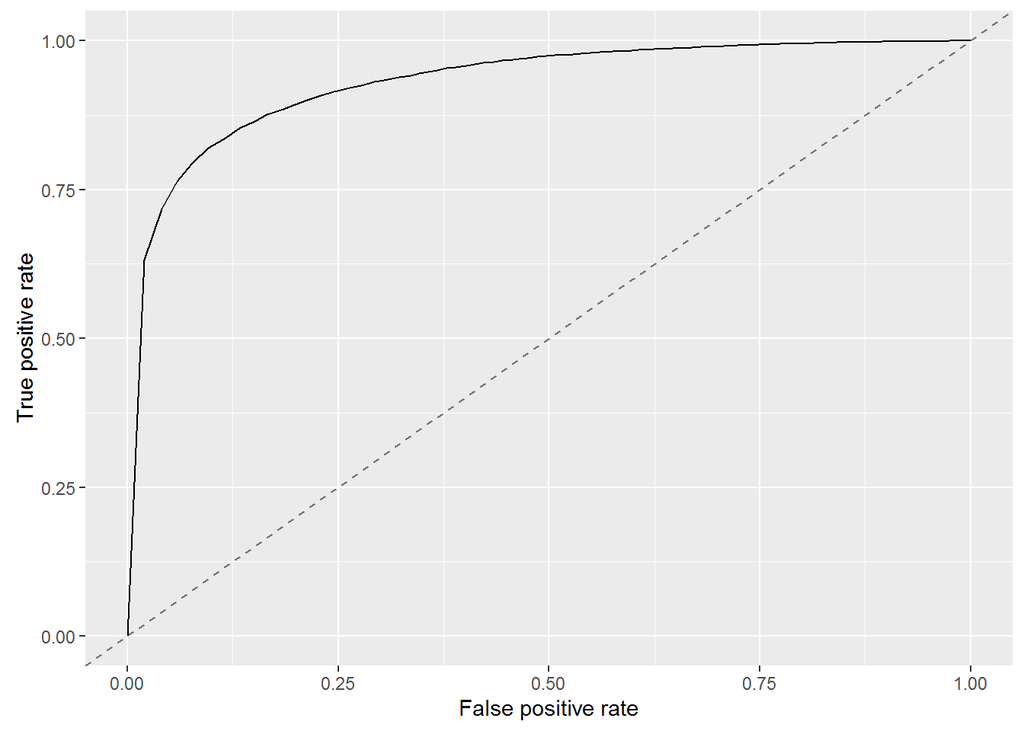

```r
df <- generateThreshVsPerfData(predict.xgprob,measures = list(fpr,tpr,auc))
plotROCCurves(df)
```

```r
df
```

```
## $measures
## $measures$fpr
## Name: False positive rate
## Performance measure: fpr
## Properties: classif,req.pred,req.truth
## Minimize: TRUE
## Best: 0; Worst: 1
## Aggregated by: test.mean
## Note: Also called false alarm rate or fall-out.
##
## $measures$tpr
## Name: True positive rate
## Performance measure: tpr
## Properties: classif,req.pred,req.truth
## Minimize: FALSE
```

[output cut: 122 more lines]

auc is 0.935871 to improve the area under curve, we should aim to reduce the threshold so that the false positive rate can be reduced.

```r
#set threshold as 0.4
pred2 <- setThreshold(predict.xgprob,0.4)
confusionMatrix(test$income_level,pred2$data$response)
```

```
## $positive
## [1] "0"
##
## $table
##           Reference
## Prediction     0     1
##          0 92934   642
##          1  4591  1595
##
## $overall
##       Accuracy          Kappa  AccuracyLower  AccuracyUpper   AccuracyNull
##      0.9475452      0.3575655      0.9461436      0.9489206      0.9775766
## AccuracyPValue  McnemarPValue
##      1.0000000      0.0000000
##
## $byClass
##          Sensitivity          Specificity       Pos Pred Value
##            0.9529249            0.7130085            0.9931393
##       Neg Pred Value            Precision               Recall
##            0.2578403            0.9931393            0.9529249
##                   F1           Prevalence       Detection Rate
##            0.9726166            0.9775766            0.9315571
## Detection Prevalence    Balanced Accuracy
##            0.9379924            0.8329667
##
## $mode
## [1] "sens_spec"
##
## $dots
## list()
##
## attr(,"class")
## [1] "confusionMatrix"
```

With 0.4 threshold, our model returned better predictions than our previous xgboost model at 0.5 threshold

```r
pred3 <- setThreshold(predict.xgprob,0.30)
confusionMatrix(test$income_level,pred3$data$response)
```

```
## $positive
## [1] "0"
##
## $table
##           Reference
## Prediction     0     1
##          0 93287   289
##          1  5175  1011
##
## $overall
##       Accuracy          Kappa  AccuracyLower  AccuracyUpper   AccuracyNull
##      0.9452296      0.2540391      0.9437997      0.9466336      0.9869690
## AccuracyPValue  McnemarPValue
##      1.0000000      0.0000000
##
## $byClass
##          Sensitivity          Specificity       Pos Pred Value
##            0.9474417            0.7776923            0.9969116
##       Neg Pred Value            Precision               Recall
##            0.1634336            0.9969116            0.9474417
##                   F1           Prevalence       Detection Rate
##            0.9715473            0.9869690            0.9350955
## Detection Prevalence    Balanced Accuracy
##            0.9379924            0.8625670
##
## $mode
## [1] "sens_spec"
##
## $dots
## list()
##
## attr(,"class")
## [1] "confusionMatrix"
```

This model has outperformed all our models i.e. in other words, this is the best model because 77% of the minority classes have been predicted correctly.

Lets see if we can improve by experimenting with parameters increased no of rounds 10 fold CV increased repetitions in random search

xgboost

```r
set.seed(2002)
xgb_learner1 <- makeLearner("classif.xgboost",predict.type = "response")
xgb_learner1$par.vals <- list(
  objective = "binary:logistic",
  eval_metric = "error",
  nrounds = 250,
  print.every.n = 50
)

#define hyperparameters for tuning
xg_ps1 <- makeParamSet(
  makeIntegerParam("max_depth",lower=3,upper=10),
  makeNumericParam("lambda",lower=0.05,upper=0.5),
  makeNumericParam("eta", lower = 0.01, upper = 0.5),
  makeNumericParam("subsample", lower = 0.50, upper = 1),
  makeNumericParam("min_child_weight",lower=2,upper=10),
  makeNumericParam("colsample_bytree",lower = 0.50,upper = 0.80)
)

#define search function
rancontrol1 <- makeTuneControlRandom(maxit = 10L) #do 10 iterations

#10 fold cross validation
set_cv1 <- makeResampleDesc("CV",iters = 10L,stratify = TRUE)

#tune parameters
xgb_tune1 <- tuneParams(learner = xgb_learner1, task = train.task, resampling = set_cv1,
                       measures = list(acc,tpr,tnr,fpr,fp,fn), par.set = xg_ps1,
                       control = rancontrol1)
```

```
## [Tune] Started tuning learner classif.xgboost for parameter set:
```

```
##                     Type len Def      Constr Req Tunable Trafo
## max_depth        integer   -   -     3 to 10   -    TRUE     -
## lambda           numeric   -   - 0.05 to 0.5   -    TRUE     -
## eta              numeric   -   - 0.01 to 0.5   -    TRUE     -
## subsample        numeric   -   -    0.5 to 1   -    TRUE     -
## min_child_weight numeric   -   -     2 to 10   -    TRUE     -
## colsample_bytree numeric   -   -  0.5 to 0.8   -    TRUE     -
```

```
## With control class: TuneControlRandom
```

```
## Imputation value: -0Imputation value: -0Imputation value: -0Imputation value: 1Imputation value: InfImputation value: Inf
```

```
## [Tune-x] 1: max_depth=5; lambda=0.146; eta=0.374; subsample=0.841; min_child_weight=8.23; colsample_bytree=0.587
```

```
## [Tune-y] 1: acc.test.mean=0.948,tpr.test.mean=0.987,tnr.test.mean=0.351,fpr.test.mean=0.649,fp.test.mean= 804,fn.test.mean= 238; time: 4.2 min; memory: 328Mb use, 6846Mb max
```

```
## [Tune-x] 2: max_depth=3; lambda=0.243; eta=0.233; subsample=0.936; min_child_weight=2.92; colsample_bytree=0.793
```

```
## [Tune-y] 2: acc.test.mean=0.948,tpr.test.mean=0.989,tnr.test.mean=0.336,fpr.test.mean=0.664,fp.test.mean= 823,fn.test.mean= 207; time: 3.3 min; memory: 328Mb use, 6846Mb max
```

```
## [Tune-x] 3: max_depth=7; lambda=0.259; eta=0.264; subsample=0.66; min_child_weight=7.25; colsample_bytree=0.714
```

```
## [Tune-y] 3: acc.test.mean=0.947,tpr.test.mean=0.986,tnr.test.mean=0.357,fpr.test.mean=0.643,fp.test.mean= 796,fn.test.mean= 269; time: 7.2 min; memory: 328Mb use, 6846Mb max
```

```
## [Tune-x] 4: max_depth=5; lambda=0.171; eta=0.295; subsample=0.855; min_child_weight=5.54; colsample_bytree=0.735
```

```
## [Tune-y] 4: acc.test.mean=0.948,tpr.test.mean=0.988,tnr.test.mean=0.351,fpr.test.mean=0.649,fp.test.mean= 803,fn.test.mean= 232; time: 4.9 min; memory: 328Mb use, 6846Mb max
```

```
## [Tune-x] 5: max_depth=5; lambda=0.279; eta=0.28; subsample=0.63; min_child_weight=7.08; colsample_bytree=0.572
```

```
## [Tune-y] 5: acc.test.mean=0.948,tpr.test.mean=0.987,tnr.test.mean=0.351,fpr.test.mean=0.649,fp.test.mean= 804,fn.test.mean= 235; time: 4.8 min; memory: 328Mb use, 6846Mb max
```

```
## [Tune-x] 6: max_depth=4; lambda=0.44; eta=0.0208; subsample=0.827; min_child_weight=6.19; colsample_bytree=0.72
```

```
## [Tune-y] 6: acc.test.mean=0.947,tpr.test.mean=0.993,tnr.test.mean=0.249,fpr.test.mean=0.751,fp.test.mean= 930,fn.test.mean= 131; time: 3.8 min; memory: 328Mb use, 6846Mb max
```

```
## [Tune-x] 7: max_depth=8; lambda=0.384; eta=0.0359; subsample=0.988; min_child_weight=4.19; colsample_bytree=0.744
```

```
## [Tune-y] 7: acc.test.mean=0.948,tpr.test.mean=0.989,tnr.test.mean=0.327,fpr.test.mean=0.673,fp.test.mean= 834,fn.test.mean= 197; time: 7.2 min; memory: 328Mb use, 6846Mb max
```

```
## [Tune-x] 8: max_depth=10; lambda=0.209; eta=0.408; subsample=0.71; min_child_weight=2.85; colsample_bytree=0.676
```

```
## [Tune-y] 8: acc.test.mean=0.941,tpr.test.mean=0.979,tnr.test.mean=0.369,fpr.test.mean=0.631,fp.test.mean= 781,fn.test.mean= 387; time: 9.1 min; memory: 328Mb use, 6846Mb max
```

```
## [Tune-x] 9: max_depth=8; lambda=0.28; eta=0.374; subsample=0.679; min_child_weight=7.58; colsample_bytree=0.666
```

```
## [Tune-y] 9: acc.test.mean=0.945,tpr.test.mean=0.983,tnr.test.mean=0.363,fpr.test.mean=0.637,fp.test.mean= 788,fn.test.mean= 310; time: 7.2 min; memory: 328Mb use, 6846Mb max
```

```
## [Tune-x] 10: max_depth=10; lambda=0.384; eta=0.378; subsample=0.941; min_child_weight=4.87; colsample_bytree=0.68
```

```
## [Tune-y] 10: acc.test.mean=0.944,tpr.test.mean=0.982,tnr.test.mean=0.367,fpr.test.mean=0.633,fp.test.mean= 784,fn.test.mean= 338; time: 8.2 min; memory: 328Mb use, 6846Mb max
```

```
## [Tune] Result: max_depth=3; lambda=0.243; eta=0.233; subsample=0.936; min_child_weight=2.92; colsample_bytree=0.793 : acc.test.mean=0.948,tpr.test.mean=0.989,tnr.test.mean=0.336,fpr.test.mean=0.664,fp.test.mean= 823,fn.test.mean= 207
```

```r
#set optimal parameters
xgb_new1 <- setHyperPars(learner = xgb_learner1, par.vals = xgb_tune1$x)

#train model
xgmodel1 <- train(xgb_new1, train.task)
#test model
predict.xg1 <- predict(xgmodel1, test.task)

#make prediction
xg_prediction1 <- predict.xg1$data$response

#make confusion matrix
xg_confused1 <- confusionMatrix(test$income_level,xg_prediction1)

precision1 <- xg_confused1$byClass['Pos Pred Value']
recall1 <- xg_confused1$byClass['Sensitivity']

f_measure1 <- 2*((precision1*recall1)/(precision1+recall1))
f_measure1
```

```
## Pos Pred Value
##      0.9728658
```

slightly better performance - 0.9728658

XG Boost outperformed naive bayes

lets get ROC xgboost ROC

```r
xgb_prob1 <- setPredictType(learner = xgb_new1,predict.type = "prob")

#train model
xgmodel_prob1 <- train(xgb_prob1,train.task)
#predict
predict.xgprob1 <- predict(xgmodel_prob1,test.task)

#predicted probabilities
predict.xgprob1$data[1:10,]
```

```
##    id truth    prob.0       prob.1 response
## 1   1     0 0.9972323 2.767748e-03        0
## 2   2     0 0.7771056 2.228944e-01        0
## 3   3     0 0.9999878 1.215957e-05        0
## 4   4     0 0.9428723 5.712767e-02        0
## 5   5     0 0.9658584 3.414157e-02        0
## 6   6     0 0.9999761 2.385899e-05        0
## 7   7     0 0.9999889 1.106579e-05        0
## 8   8     0 0.9968390 3.161038e-03        0
## 9   9     0 0.7946936 2.053064e-01        0
## 10 10     0 0.9999895 1.045477e-05        0
```

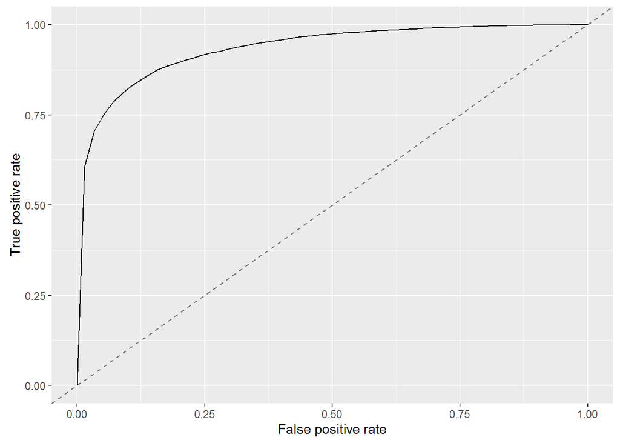

```r
df1 <- generateThreshVsPerfData(predict.xgprob1,measures = list(fpr,tpr,auc))
plotROCCurves(df1)
```

```r
df1
```

```
## $measures
## $measures$fpr
## Name: False positive rate
## Performance measure: fpr
## Properties: classif,req.pred,req.truth
## Minimize: TRUE
## Best: 0; Worst: 1
## Aggregated by: test.mean
## Note: Also called false alarm rate or fall-out.
##
## $measures$tpr
## Name: True positive rate
## Performance measure: tpr
## Properties: classif,req.pred,req.truth
## Minimize: FALSE
```

[output cut: 122 more lines]

To improve the area under curve, we should aim to reduce the threshold so that the false positive rate can be reduced.

```r
pred4 <- setThreshold(predict.xgprob1,0.30)
confusionMatrix(test$income_level,pred4$data$response)
```

```
## $positive
## [1] "0"
##
## $table
##           Reference
## Prediction     0     1
##          0 93329   247
##          1  5234   952
##
## $overall
##       Accuracy          Kappa  AccuracyLower  AccuracyUpper   AccuracyNull
##      0.9450592      0.2425693      0.9436273      0.9464653      0.9879814
## AccuracyPValue  McnemarPValue
##      1.0000000      0.0000000
##
## $byClass
##          Sensitivity          Specificity       Pos Pred Value
##            0.9468969            0.7939950            0.9973604
##       Neg Pred Value            Precision               Recall
##            0.1538959            0.9973604            0.9468969
##                   F1           Prevalence       Detection Rate
##            0.9714738            0.9879814            0.9355165
## Detection Prevalence    Balanced Accuracy
##            0.9379924            0.8704460
##
## $mode
## [1] "sens_spec"
##
## $dots
## list()
##
## attr(,"class")
## [1] "confusionMatrix"
```

SVM - taking forever now lets assign weights to tell the algorithm to pay more attention while classifying minority class

getParamSet(“classif.svm”) svm_learner <- makeLearner(“classif.svm”,predict.type = “response”) assining more weight to class 1 svm_learner$par.vals<- list(class.weights = c(“0”=1,“1”=10),kernel=“radial”)

svm_param <- makeParamSet( makeIntegerParam(“cost”,lower = 10^-1,upper = 10^2), makeIntegerParam(“gamma”,lower= 0.5,upper = 2) )

random search set_search <- makeTuneControlRandom(maxit = 1L) 3 times

cross validation 10L seem to take forever set_cv <- makeResampleDesc(“CV”,iters=2L,stratify = TRUE)

tune Params svm_tune <- tuneParams(learner = svm_learner, task = train.task, measures = list(acc,tpr,tnr,fpr,fp,fn), par.set = svm_param, control = set_search ,resampling = set_cv)

set hyperparameters svm_new <- setHyperPars(learner = svm_learner, par.vals = svm_tune$x)

train model svm_model <- train(svm_new,train.task)

test model predict_svm <- predict(svm_model,test.task)